# RussellRanch_V1_Data

J Sorensen

1/28/2020

# 1 Initial Data Cleaning and Setup

Want to separate out the Bulk vs Virome OTU tables so we can do some stats on each of them separately later.

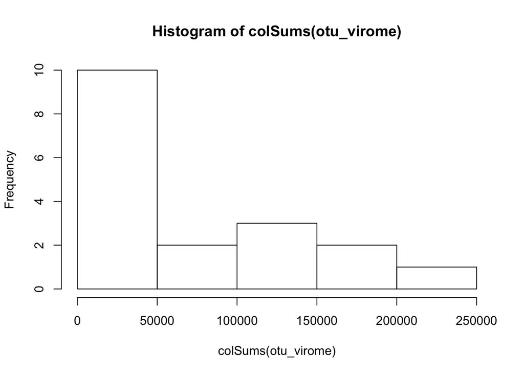

```r
library(tidyverse)
library(ggplot2)
library(vegan)
library(grid)
library(cowplot)

setwd("~/Documents/UCD/GitHubRepos/RussellRanch/R")

map <- read_delim("InputFiles/RussellRanch_Map.txt", col_names = TRUE, delim = "\t")

map$Management <- gsub(pattern="C", replacement="Conventional", map$Management)
map$Management <- gsub(pattern = "O", replacement="Organic", map$Management)

map <- map %>%
  select(-Year, -Crop)

map$Date_Sample <- paste(map$Month,map$Sample_1, sep = "_")
map$Date_Factor <- factor(map$Month, levels=c("2018-07-07", "2018-10-08"))


map_Bulk <- filter(map, BulkVsVirome=="Bulk")
map_Virome <- filter(map, BulkVsVirome=="Virome")

otu <- read_delim("InputFiles/Viral_Coverage_Table_190905.txt", delim="\t", col_names = TRUE)

Contig_Length <- otu[,1:2]
otu <- otu %>%
  select(-contig, -Length)

otu <- as.data.frame(otu)
row.names(otu) <- Contig_Length$contig


otu_bulk <- otu[,colnames(otu)%in%map_Bulk$Sample]
otu_virome <- otu[,colnames(otu)%in%map_Virome$Sample]
#colnames(otu_virome)==map_Virome$Sample
#colnames(otu_bulk)==map_Bulk$Sample

hist(colSums(otu_virome))
```

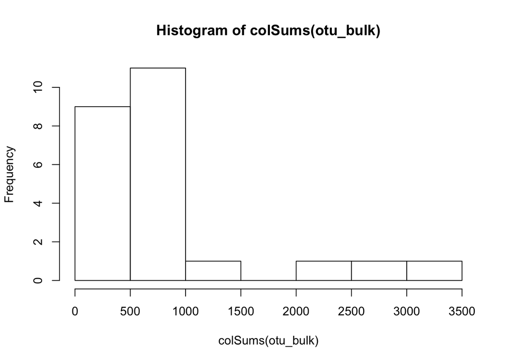

```r
hist(colSums(otu_bulk))
```

```r
otu_bulk_sub <- otu_bulk[,map_Bulk$Date_Sample%in%map_Virome$Date_Sample]
otu_virome_sub <- otu_virome[map_Virome$Date_Sample%in%map_Bulk$Date_Sample]

map_bulk_sub <- map_Bulk[map_Bulk$Date_Sample%in%map_Virome$Date_Sample,]

map_bulk_sub$Sample==colnames(otu_bulk_sub)
```

```
##  [1] TRUE TRUE TRUE TRUE TRUE TRUE TRUE TRUE TRUE TRUE TRUE TRUE TRUE TRUE TRUE
## [16] TRUE TRUE TRUE
```

```r
map_bulk_sub$Date_Sample==map_Virome$Date_Sample
```

```
##  [1] TRUE TRUE TRUE TRUE TRUE TRUE TRUE TRUE TRUE TRUE TRUE TRUE TRUE TRUE TRUE
## [16] TRUE TRUE TRUE
```

# 2 Beta Diversity Analyses

Now that our data sets are cleaned up and ready to go, let’s start looking at the overall patterns in the datasets.

## 2.1 Setting up Bray Curtis Dissimilarities and PCoAs

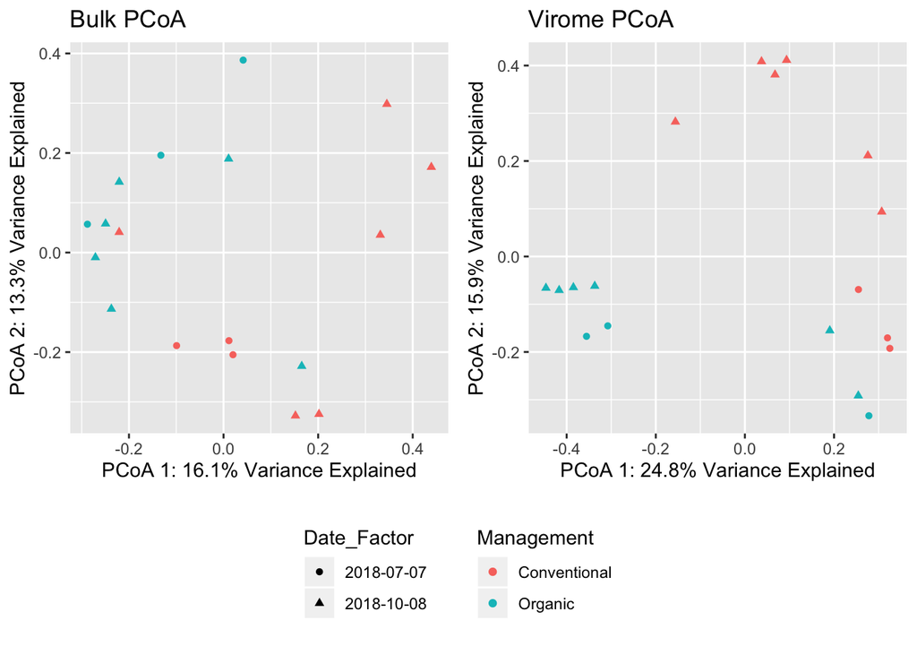

```r
otu_bulk_sub.dist <- vegdist(t(otu_bulk_sub), method="bray")
otu_virome.dist <- vegdist(t(otu_virome_sub),method="bray")

otu_bulk_sub.pcoa <- cmdscale(otu_bulk_sub.dist, eig = TRUE)
otu_virome.pcoa <- cmdscale(otu_virome.dist, eig=TRUE)

bulk.eig1 <- otu_bulk_sub.pcoa$eig[1]/sum(otu_bulk_sub.pcoa$eig)
bulk.eig2 <- otu_bulk_sub.pcoa$eig[2]/sum(otu_bulk_sub.pcoa$eig)

virome.eig1 <- otu_virome.pcoa$eig[1]/sum(otu_virome.pcoa$eig)
virome.eig2 <- otu_virome.pcoa$eig[2]/sum(otu_virome.pcoa$eig)



map_Virome$PCoA1 <- otu_virome.pcoa$points[,1]
map_Virome$PCoA2 <- otu_virome.pcoa$points[,2]

map_bulk_sub$PCoA1 <- otu_bulk_sub.pcoa$points[,1]
map_bulk_sub$PCoA2 <- otu_bulk_sub.pcoa$points[,2]

Virome_PCoA <- ggplot(map_Virome, aes(x=PCoA1, y=PCoA2))+
  geom_point(aes(shape= Date_Factor, color=Management))+
  xlab(label = paste("PCoA 1: ", round(virome.eig1, 3)*100, "% Variance Explained", sep=""))+
  ylab(label = paste("PCoA 2: ", round(virome.eig2, 3)*100, "% Variance Explained", sep=""))+
  ggtitle(label="Virome PCoA")+
  guides(color=FALSE, size=FALSE, shape=FALSE, fill=FALSE )



Bulk_PCoA <- ggplot(map_bulk_sub, aes(x=PCoA1, y=PCoA2))+
  geom_point(aes(shape=Date_Factor, color=Management))+
  xlab(label = paste("PCoA 1: ", round(bulk.eig1, 3)*100, "% Variance Explained", sep=""))+
  ylab(label = paste("PCoA 2: ", round(bulk.eig2, 3)*100, "% Variance Explained", sep=""))+
  ggtitle(label="Bulk PCoA")+
  guides(color=FALSE, size=FALSE, shape=FALSE, fill=FALSE )

PCoA_Legend <- ggplot(map_bulk_sub, aes(x=PCoA1, y=PCoA2))+
  geom_point(aes(shape=Date_Factor, color=Management))+
  xlab(label = paste("PCoA 1: ", round(bulk.eig1, 3)*100, "% Variance Explained", sep=""))+
  ylab(label = paste("PCoA 2: ", round(bulk.eig2, 3)*100, "% Variance Explained", sep=""))+
  ggtitle(label="Bulk PCoA")+
  theme(legend.box = "horizontal")

PCoA_Leg <- get_legend(PCoA_Legend)

plot_grid(plot_grid(Bulk_PCoA, Virome_PCoA, ncol=2), PCoA_Leg, ncol=1, rel_heights = c(3,1))
```

Initial glances at the PCoAs suggests the samples cluster by Management practice more so than by time/Date.

## 2.2 Do the two datasets show similar patterns overall?

Using Mantel tests and Procrustes to see if the Bulk and Virome datasets are similar overall.

```r
mantel(otu_virome.dist, otu_bulk_sub.dist)
```

```
##
## Mantel statistic based on Pearson's product-moment correlation
##
## Call:
## mantel(xdis = otu_virome.dist, ydis = otu_bulk_sub.dist)
##
## Mantel statistic r: 0.3264
##       Significance: 0.001
##
## Upper quantiles of permutations (null model):
##   90%   95% 97.5%   99%
## 0.110 0.139 0.175 0.207
## Permutation: free
## Number of permutations: 999
```

```r
protest(otu_virome.pcoa, otu_bulk_sub.pcoa)
```

```
##
## Call:
## protest(X = otu_virome.pcoa, Y = otu_bulk_sub.pcoa)
##
## Procrustes Sum of Squares (m12 squared):        0.5914
## Correlation in a symmetric Procrustes rotation: 0.6392
## Significance:  0.001
##
## Permutation: free
## Number of permutations: 999
```

Both Mantel tests and Procrustes suggest the two datasets show the same patterns overall. Perhaps this means we could just use the bulk for tests we need more power for? Hmm not totally sure…

## 2.3 Now for some hypothesis tests

Testing for influence of Management and Dat first. Using adonis() to perform permanovas, using anosim() for ANOSIM test.

```r
adonis(otu_virome.dist~map_Virome$Management*map_Virome$Date_Factor)
```

```
##
## Call:
## adonis(formula = otu_virome.dist ~ map_Virome$Management * map_Virome$Date_Factor)
##
## Permutation: free
## Number of permutations: 999
##
## Terms added sequentially (first to last)
##
##                                              Df SumsOfSqs MeanSqs F.Model
## map_Virome$Management                         1    1.0576 1.05761  3.8906
## map_Virome$Date_Factor                        1    0.7743 0.77428  2.8483
## map_Virome$Management:map_Virome$Date_Factor  1    0.4754 0.47535  1.7487
## Residuals                                    14    3.8057 0.27184
## Total                                        17    6.1129
##                                                   R2 Pr(>F)
## map_Virome$Management                        0.17301  0.001 ***
## map_Virome$Date_Factor                       0.12666  0.002 **
## map_Virome$Management:map_Virome$Date_Factor 0.07776  0.055 .
## Residuals                                    0.62256
## Total                                        1.00000
## ---
## Signif. codes:  0 '***' 0.001 '**' 0.01 '*' 0.05 '.' 0.1 ' ' 1
```

```r
adonis(otu_virome.dist~map_Virome$Management+map_Virome$Date_Factor)
```

```
##
## Call:
## adonis(formula = otu_virome.dist ~ map_Virome$Management + map_Virome$Date_Factor)
##
## Permutation: free
## Number of permutations: 999
##
## Terms added sequentially (first to last)
##
##                        Df SumsOfSqs MeanSqs F.Model      R2 Pr(>F)
## map_Virome$Management   1    1.0576 1.05761  3.7057 0.17301  0.001 ***
## map_Virome$Date_Factor  1    0.7743 0.77428  2.7129 0.12666  0.009 **
## Residuals              15    4.2811 0.28540         0.70033
## Total                  17    6.1129                 1.00000
## ---
## Signif. codes:  0 '***' 0.001 '**' 0.01 '*' 0.05 '.' 0.1 ' ' 1
```

```r
adonis(otu_virome.dist~map_Virome$Management)
```

```
##
## Call:
## adonis(formula = otu_virome.dist ~ map_Virome$Management)
##
## Permutation: free
## Number of permutations: 999
##
## Terms added sequentially (first to last)
##
##                       Df SumsOfSqs MeanSqs F.Model      R2 Pr(>F)
## map_Virome$Management  1    1.0576 1.05761  3.3473 0.17301  0.003 **
## Residuals             16    5.0553 0.31596         0.82699
## Total                 17    6.1129                 1.00000
## ---
## Signif. codes:  0 '***' 0.001 '**' 0.01 '*' 0.05 '.' 0.1 ' ' 1
```

```r
adonis(otu_virome.dist~map_Virome$Date_Factor)
```

```
##
## Call:
## adonis(formula = otu_virome.dist ~ map_Virome$Date_Factor)
##
## Permutation: free
## Number of permutations: 999
##
## Terms added sequentially (first to last)
##
##                        Df SumsOfSqs MeanSqs F.Model      R2 Pr(>F)
## map_Virome$Date_Factor  1    0.7743 0.77428  2.3205 0.12666  0.012 *
## Residuals              16    5.3387 0.33367         0.87334
## Total                  17    6.1129                 1.00000
## ---
## Signif. codes:  0 '***' 0.001 '**' 0.01 '*' 0.05 '.' 0.1 ' ' 1
```

```r
anosim(otu_virome.dist, grouping = map_Virome$Management)
```

```
##
## Call:
## anosim(x = otu_virome.dist, grouping = map_Virome$Management)
## Dissimilarity: bray
##
## ANOSIM statistic R: 0.4366
##       Significance: 0.003
##
## Permutation: free
## Number of permutations: 999
```

```r
anosim(otu_virome.dist, grouping= map_Virome$Date_Factor)
```

```
##
## Call:
## anosim(x = otu_virome.dist, grouping = map_Virome$Date_Factor)
## Dissimilarity: bray
##
## ANOSIM statistic R: 0.3549
##       Significance: 0.009
##
## Permutation: free
## Number of permutations: 999
```

For both PERMANOVA and ANOSIM, Management practice appears to have a bigger influence than time.

## 2.4 What about beta dispersion?

Are both management practices equivalent in their betadispersion?

```r
Disper_Management <- betadisper(otu_virome.dist, group=map_Virome$Management)
Disper_Management
```

```
##
##  Homogeneity of multivariate dispersions
##
## Call: betadisper(d = otu_virome.dist, group = map_Virome$Management)
##
## No. of Positive Eigenvalues: 17
## No. of Negative Eigenvalues: 0
##
## Average distance to median:
## Conventional      Organic
##       0.4927       0.5577
##
## Eigenvalues for PCoA axes:
## (Showing 8 of 17 eigenvalues)
##  PCoA1  PCoA2  PCoA3  PCoA4  PCoA5  PCoA6  PCoA7  PCoA8
## 1.5167 0.9718 0.7893 0.5074 0.4471 0.3210 0.2729 0.2381
```

```r
TukeyHSD(Disper_Management)
```

```
##   Tukey multiple comparisons of means
##     95% family-wise confidence level
##
## Fit: aov(formula = distances ~ group, data = df)
##
## $group
##                            diff         lwr       upr     p adj
## Organic-Conventional 0.06495478 -0.01307277 0.1429823 0.0966855
```

```r
Disper_Date <- betadisper(otu_virome.dist, group=map_Virome$Date_Factor)
Disper_Date
```

```
##
##  Homogeneity of multivariate dispersions
##
## Call: betadisper(d = otu_virome.dist, group = map_Virome$Date_Factor)
##
## No. of Positive Eigenvalues: 17
## No. of Negative Eigenvalues: 0
##
## Average distance to median:
## 2018-07-07 2018-10-08
##     0.5371     0.5425
##
## Eigenvalues for PCoA axes:
## (Showing 8 of 17 eigenvalues)
##  PCoA1  PCoA2  PCoA3  PCoA4  PCoA5  PCoA6  PCoA7  PCoA8
## 1.5167 0.9718 0.7893 0.5074 0.4471 0.3210 0.2729 0.2381
```

```r
TukeyHSD(Disper_Date)
```

```
##   Tukey multiple comparisons of means
##     95% family-wise confidence level
##
## Fit: aov(formula = distances ~ group, data = df)
##
## $group
##                              diff         lwr        upr     p adj
## 2018-10-08-2018-07-07 0.005356139 -0.08349113 0.09420341 0.8999013
```

# 3 Alpha Diversity

## 3.1 Richness

Calculating and plotting Richness based on management practice and date

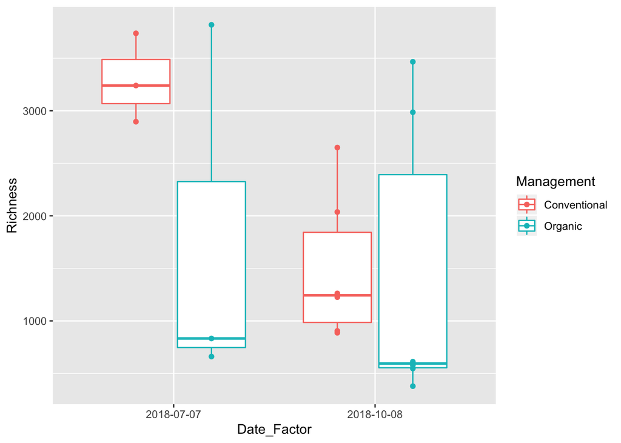

```r
virome_PA <- 1*(otu_virome>0)

map_Virome$Richness <- colSums(virome_PA)

ggplot(map_Virome, aes(x=Date_Factor, y=Richness))+
  geom_boxplot(aes(group=interaction(Date_Factor, Management), color=Management))+
  geom_point(position=position_dodge(width=0.75),aes(color=Management))
```

## 3.2 Testing Richness differences

Using Kruskal-Wallis non parametic test to test for the differences between conventional and organic management practices.

```r
#July Test
map_Virome_July <- map_Virome[map_Virome$Date_Factor=="2018-07-07",]
kruskal.test(map_Virome_July$Richness, g = map_Virome_July$Management)
```

```
##
##  Kruskal-Wallis rank sum test
##
## data:  map_Virome_July$Richness and map_Virome_July$Management
## Kruskal-Wallis chi-squared = 0.42857, df = 1, p-value = 0.5127
```

```r
map_Virome_Oct <- map_Virome[map_Virome$Date_Factor=="2018-10-08",]
kruskal.test(map_Virome_Oct$Richness, g=map_Virome_Oct$Management)
```

```
##
##  Kruskal-Wallis rank sum test
##
## data:  map_Virome_Oct$Richness and map_Virome_Oct$Management
## Kruskal-Wallis chi-squared = 0.92308, df = 1, p-value = 0.3367
```

No significant difference in Richness between management practices according to Kruksal Wallis test.

# 4 Indicator Species Analysis

We have a relatively few number of taxa present in the study. Perhaps we could run an indicator species analysis and see if there are certain viral contigs associated with management types.

```r
library(indicspecies)
indval <- multipatt(t(otu_virome), map_Virome$Management, control = how(nperm=999))

summary(indval)
```

```
##
##  Multilevel pattern analysis
##  ---------------------------
##
##  Association function: IndVal.g
##  Significance level (alpha): 0.05
##
##  Total number of species: 8021
##  Selected number of species: 703
##  Number of species associated to 1 group: 703
##
##  List of species associated to each combination:
##
##  Group Conventional  #sps.  527
##                                        stat p.value
## RR132July_vir_S9_L001_virsorter_581   1.000   0.001 ***
## RR132Oct_vir_S16_L001_virsorter_149   1.000   0.001 ***
## RR451Oct_vir_S11_L001_virsorter_316   1.000   0.001 ***
## RR451Oct_vir_S11_L001_virsorter_51    1.000   0.001 ***
## RR452Oct_vir_S6_L001_virfinder_779    1.000   0.001 ***
## RR452Oct_vir_S6_L001_virsorter_304    1.000   0.001 ***
## RR452Oct_vir_S6_L001_virsorter_688    1.000   0.001 ***
## RR891Oct_vir_S15_L001_virsorter_30    1.000   0.001 ***
## RR891Oct_vir_S15_L001_virsorter_43    1.000   0.001 ***
## RR131Oct_vir_S17_L001_virsorter_51    0.997   0.001 ***
## RR891Oct_vir_S15_L001_virsorter_115   0.996   0.001 ***
## RR451July_vir_S10_L001_virsorter_447  0.995   0.001 ***
## RR131Oct_vir_S17_L001_virfinder_65    0.995   0.001 ***
## RR132Oct_vir_S16_L001_virfinder_18    0.994   0.001 ***
## RR451Oct_vir_S11_L001_virsorter_111   0.993   0.001 ***
## RR132Oct_vir_S16_L001_virsorter_90    0.991   0.001 ***
## RR682Oct_vir_S8_L001_virsorter_436    0.990   0.001 ***
## RR892Oct_vir_S23_L001_virfinder_1     0.989   0.001 ***
## RR132Oct_Bulk_S20_L001_virsorter_17   0.988   0.001 ***
## RR892Oct_vir_S23_L001_virsorter_144   0.988   0.001 ***
## RR132Oct_vir_S16_L001_virsorter_200   0.988   0.001 ***
## RR892Oct_vir_S23_L001_virsorter_145   0.987   0.001 ***
## RR131Oct_vir_S17_L001_virsorter_252   0.987   0.001 ***
## RR891July_vir_S2_L001_virsorter_34    0.987   0.001 ***
## RR451Oct_vir_S11_L001_virsorter_334   0.986   0.001 ***
```

[output cut: 668 more lines]

```
## RR682Oct_vir_S8_L001_virsorter_700    0.745   0.027 *
## RR682Oct_vir_S8_L001_virsorter_740    0.745   0.028 *
## RR682Oct_vir_S8_L001_virsorter_764    0.745   0.029 *
## RR681July_vir_S24_L001_virsorter_20   0.744   0.040 *
## RR641Oct_vir_S1_L001_virsorter_316    0.744   0.024 *
## RR641Oct_vir_S1_L001_virsorter_611    0.744   0.047 *
## RR641Oct_vir_S1_L001_virsorter_766    0.742   0.031 *
## RR642July_vir_S5_L001_virsorter_767   0.736   0.017 *
## RR642July_vir_S5_L001_virsorter_1250  0.736   0.017 *
## RR682Oct_vir_S8_L001_virsorter_728    0.735   0.048 *
## RR682Oct_vir_S8_L001_virfinder_422    0.734   0.045 *
## RR642July_vir_S5_L001_virfinder_697   0.732   0.033 *
## RR232Oct_vir_S28_L001_virsorter_34    0.727   0.043 *
## ---
## Signif. codes:  0 '***' 0.001 '**' 0.01 '*' 0.05 '.' 0.1 ' ' 1
```